# Regression Models Project

Tonya MacDonald

2/21/2021

## Overview

This assignment is to analyze a dataset to see what factors have the largest impact on mile per gallon, in paticular to see if the following questions can be answered:

1. “Is an automatic or manual transmission better for MPG”
2. “Quantify the MPG difference between automatic and manual transmissions”

### Data Prep

```r
# load packaes and dataset
library(ggplot2)
data(mtcars)
```

```r
# convert to factors
mtcars$vs <- factor(mtcars$vs)
mtcars$gear <- factor(mtcars$gear)
mtcars$carb <- factor(mtcars$carb)
mtcars$transmissiontype <- factor(mtcars$am, labels=c("Automatic","Manual"))
head(mtcars)
```

```
##                    mpg cyl disp  hp drat    wt  qsec vs am gear carb
## Mazda RX4         21.0   6  160 110 3.90 2.620 16.46  0  1    4    4
## Mazda RX4 Wag     21.0   6  160 110 3.90 2.875 17.02  0  1    4    4
## Datsun 710        22.8   4  108  93 3.85 2.320 18.61  1  1    4    1
## Hornet 4 Drive    21.4   6  258 110 3.08 3.215 19.44  1  0    3    1
## Hornet Sportabout 18.7   8  360 175 3.15 3.440 17.02  0  0    3    2
## Valiant           18.1   6  225 105 2.76 3.460 20.22  1  0    3    1
##                   transmissiontype
## Mazda RX4                   Manual
## Mazda RX4 Wag               Manual
## Datsun 710                  Manual
## Hornet 4 Drive           Automatic
## Hornet Sportabout        Automatic
## Valiant                  Automatic
```

### Data Analysis

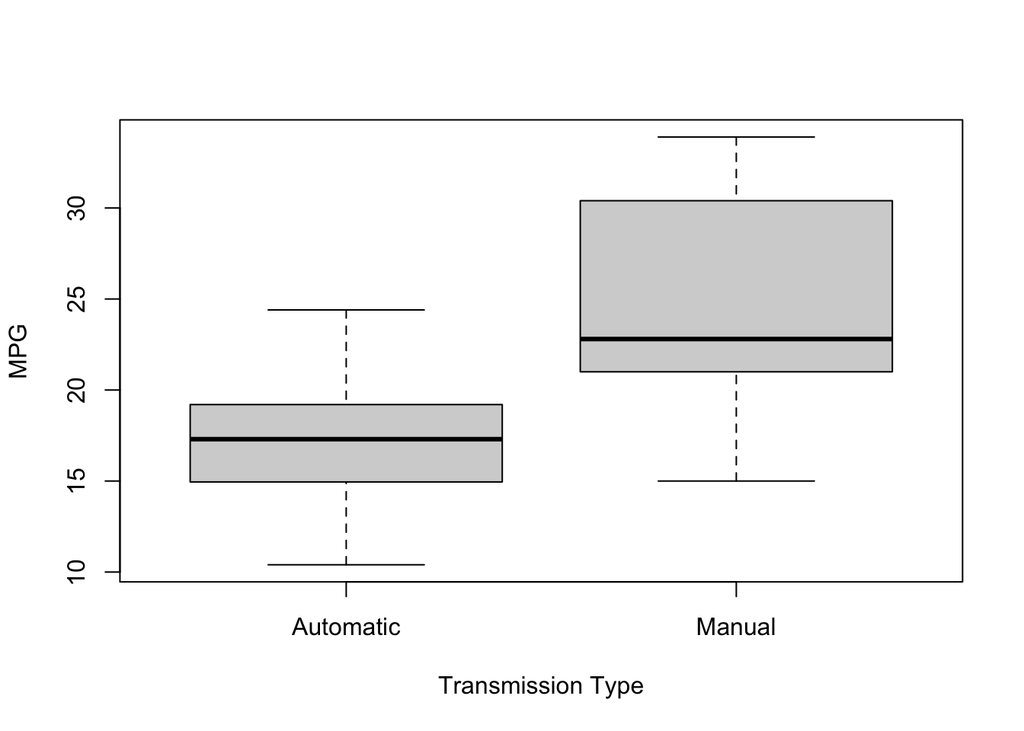

```r
# create a boxplot of tranmission type vs mpg
boxplot(mpg ~ transmissiontype, data = mtcars, ylab = "MPG", xlab = "Transmission Type")
```

This boxplot shows a clear indication that manual transmissions have higher mpg than automatic.

We will review the data to see if there are other factors that impact mpg.

```r
# create a linear regression of mpg vs transmission type
linreg <- lm(mpg ~ factor(am), data=mtcars)
summary(linreg)
```

```
##
## Call:
## lm(formula = mpg ~ factor(am), data = mtcars)
##
## Residuals:
##     Min      1Q  Median      3Q     Max
## -9.3923 -3.0923 -0.2974  3.2439  9.5077
##
## Coefficients:
##             Estimate Std. Error t value Pr(>|t|)
## (Intercept)   17.147      1.125  15.247 1.13e-15 ***
## factor(am)1    7.245      1.764   4.106 0.000285 ***
## ---
## Signif. codes:  0 '***' 0.001 '**' 0.01 '*' 0.05 '.' 0.1 ' ' 1
##
## Residual standard error: 4.902 on 30 degrees of freedom
## Multiple R-squared:  0.3598, Adjusted R-squared:  0.3385
## F-statistic: 16.86 on 1 and 30 DF,  p-value: 0.000285
```

Here we can see that the p-value is very low (p-value: 0.000285), so transmission type has a big effect on mpg.

However, the R-squared value is 0.3598, so this means that about 36% of the mpg variance is from transmission type.

```r
# see what other factors impact the mpg variance
mpgvar <- aov(mpg ~ ., data = mtcars)
summary(mpgvar)
```

```
##             Df Sum Sq Mean Sq F value  Pr(>F)
## cyl          1  817.7   817.7 102.591 2.3e-08 ***
## disp         1   37.6    37.6   4.717 0.04525 *
## hp           1    9.4     9.4   1.176 0.29430
## drat         1   16.5    16.5   2.066 0.16988
## wt           1   77.5    77.5   9.720 0.00663 **
## qsec         1    3.9     3.9   0.495 0.49161
## vs           1    0.1     0.1   0.016 0.90006
## am           1   14.5    14.5   1.816 0.19657
## gear         2    2.3     1.2   0.145 0.86578
## carb         5   19.0     3.8   0.477 0.78789
## Residuals   16  127.5     8.0
## ---
## Signif. codes:  0 '***' 0.001 '**' 0.01 '*' 0.05 '.' 0.1 ' ' 1
```

Here we see that number of cylinders (cyl), weight (wt), and displacement (disp) have low p-values and we should take a closer look.

```r
# create a linear regression of mpg vs number of cylinders, weight, displacement, and transmission type
multilinreg <- lm(mpg ~ cyl + disp + wt + am, data = mtcars)
summary(multilinreg)
```

```
##
## Call:
## lm(formula = mpg ~ cyl + disp + wt + am, data = mtcars)
##
## Residuals:
##    Min     1Q Median     3Q    Max
## -4.318 -1.362 -0.479  1.354  6.059
##
## Coefficients:
##              Estimate Std. Error t value Pr(>|t|)
## (Intercept) 40.898313   3.601540  11.356 8.68e-12 ***
## cyl         -1.784173   0.618192  -2.886  0.00758 **
## disp         0.007404   0.012081   0.613  0.54509
## wt          -3.583425   1.186504  -3.020  0.00547 **
## am           0.129066   1.321512   0.098  0.92292
## ---
## Signif. codes:  0 '***' 0.001 '**' 0.01 '*' 0.05 '.' 0.1 ' ' 1
##
## Residual standard error: 2.642 on 27 degrees of freedom
## Multiple R-squared:  0.8327, Adjusted R-squared:  0.8079
## F-statistic: 33.59 on 4 and 27 DF,  p-value: 4.038e-10
```

Including the additional variables accounts for about 83% of the variance now (R-squared = 0.8327)

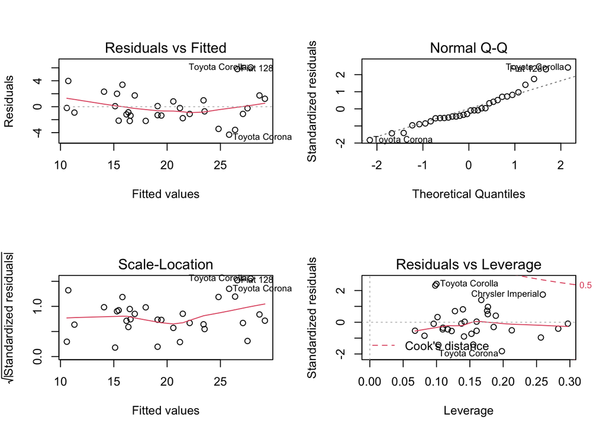

```r
par(mfrow = c(2,2))
plot(multilinreg)
```

### Summary

Looking at only transmission type, the average mpg The average mpg by transmission type is about 17 mpg for automatic transmissions, and 24 mpg for manual.

```r
aggregate(mtcars$mpg,by=list(mtcars$transmissiontype),FUN=mean)
```

```
##     Group.1        x
## 1 Automatic 17.14737
## 2    Manual 24.39231
```